# Estimering av strømstøtte

2022-10-07

*Av [Martin Jullum, Norsk Regnesentral](https://nr.no/ansatte/martin-jullum/).*

**Oppdatering 1. sept 2023**: Etter at regjeringen endret strømstøtteordningen til timesbasert avregning fra 1.september 2023, er den faktiske strømstøtten kjent umiddelbart. Det er dermed ikke lenger behov for å estimere strømstøtten, som var hovedformålet med dette prosjektet. Prognosemodellene ble derfor stoppet 30.08.2023. Dokumentasjonen av hvordan modelleringen ble utført (se under) er imidlertid beholdt i sin helhet da den kan være av metodisk interesse.

**Oppdatering 18. des 2022**: På dinstrompris.no har jeg nå laget en tjeneste der du basert på ditt postnummer får se din faktiske strømpris inkludert både spotpris, strømstøtte og nettleie. Strømstøtteestimatene jeg bruker på den siden er de sammen som vist nedenfor.

Estimater sist oppdatert 30.08.2023

## Bakgrunn

Statens strømstøtteordning gir støtte til husholdninger per kWh. Støtten fastsettes etter månedsslutt basert på månedens gjennomsnittlige spotpris. Støtteordningen tar altså ikke hensyn til hva spotprisen er i periodene man bruker mest og minst strøm. Siden spotprisen en bestemt dag fastsettes først dagen før, vet man heller ikke hvor stor støtten blir før nest siste dag i måneden. Med andre ord vet man ikke hvor mye man i praksis må betale for strømmen når man bruker den!

Mediehus som [VG](https://www.vg.no/spesial/2022/stromprisene/) og [Aftenposten](https://www.aftenposten.no/emne/str%C3%B8mprisene) presenterer daglig den gjennomsnittlige spotprisen så langt i måneden, og beregner strømstøtten under antagelsen om at resten av måneden har samme gjennomsnittlige spotpris). Et slikt regnestykke tar imidlertid ikke hensyn til hvilke ukedager som gjenstår i måneden (spotprisen er typisk lavere i helgene), og hvordan spotprisen har utviklet seg de siste dagene. Og kanskje viktigst av alt: Det sier heller ingenting om usikkerheten. Etter hvert som måneden går observerer man jo en større og større andel av månedens spotpriser, og blir dermed sikrere og sikrere på hva strømstøtten lander på – uansett hva slags tallmateriale man legger til grunn!

Kan vi si noe mer fornuftig om hva vi til en hver tid tror månedens strømstøtte ender på? Og hvor sikre er vi på det vi tror?

I et forsøk på å svare på disse spørsmålene har jeg estimert den gjennomsnittlige spotprisen for måneden gjennom å modellere, og så predikere, daglig spotpris for de gjenværende dagene i måneden. Dette gjøres separat for hvert av de 5 prisområdene i Norge. Kombinert med den gjennomsnittlige spotprisen så langt i måneden gir dette et estimat på månedens strømstøtte med usikkerhetsintervaller. Estimatene oppdateres automatisk ca kl. 13.30, når neste dags spotpris blir offentliggjort.

## Estimater

Tabellen nedenfor viser estimat og 95 % konfidensintervall for månedlig strømpris og dertilhørende strømstøtte for hvert av de fem prisområdene med siste tilgjengelige spotpriser. Konfidensintervallet viser hvilket intervall den faktiske månedelige spotprisen/strømstøtten vil ligge innenfor i 95 % av gangene dette gjentas. I tillegg til estimatene vises “Absolutt nedre grense” svarende til at strømprisen blir 0 NOK/kWh resten av måneden, mens “Så langt denne måneden” angir hva månedelig spotpris/strømstøtte blir hvis gjennomsnittet resten av måneden blir helt likt slik det har vært så langt denne måneden. Tallene inkluderer mva, men ikke fast eller variabel nettleie, eller andre påslag fra nettleverandør.

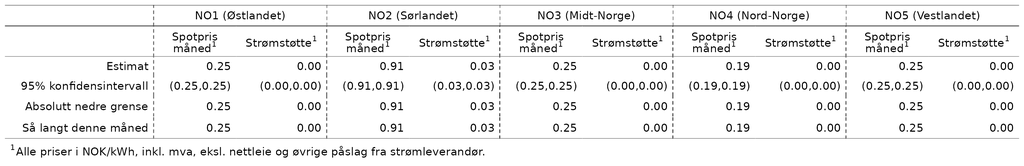

Figuren nedenfor gir en visuell fremstilling av utviklingen til strømstøttetallene fra tabellen overfor slik de har endret seg fra dag til dag så langt denne måneden.

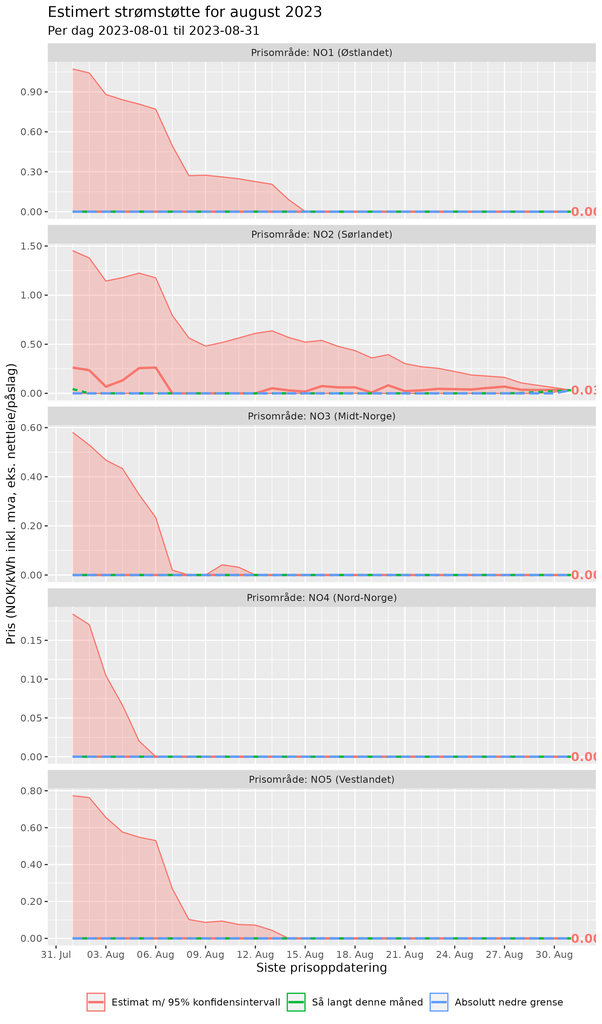

Figuren nedenfor gir en visuell fremstilling av utviklingen av tallene knyttet til månedlig spotpris fra tabellen overfor slik de har endret seg fra dag til dag så langt denne måneden. Daglig spotpris er markert med prikker for å delvis forklaring hvorfor utviklingen er som den er.

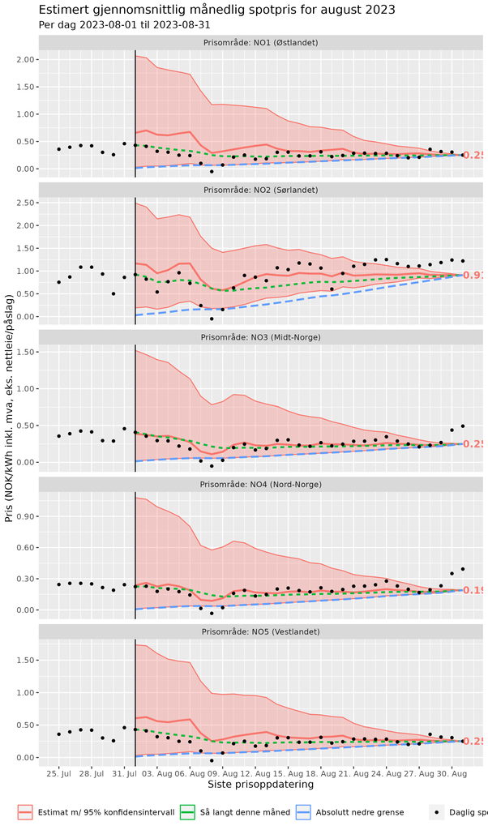

## Metode (for spesielt interesserte)

Estimering av fremtidige strømpriser er med dagens kraftmarked og internasjonale kraftledninger ingen enkel oppgave. Hvor mye det regner på Vestlandet, blåser i Tyskland og forbrukes i Sverige har betydning for strømprisen i Oslo. Mine flinke kolleger på NR har i en årrekke jobbet med [avansert modellering av strømpriser](https://nr.no/bransjer/finans-og-forsikring/ravaremarkeder/) på både kort og lang sikt.

I dette tilfelle er det imidlertid usikkerheten som er hovedfokuset. Jeg har derfor lagt til grunn en relativt enkel modell bygget på historiske spotpriser mellom 1. november 2021 og 31. august 2022. Modellen modellerer daglige spotpriser separat for hvert prisområde, og hensyntar at morgendagens spotpris empirisk avhenger av spotprisen de siste dagene, samt hvilken ukedag det er.

#### Prediksjon av spotpriser og estimering av strømstøtte

Estimerte månedelige spotpriser beregnes ved at de tilpassede modellene for hver område brukes til å simulere spotpriser for de resterende dagene i måneden mange (10 000) ganger. Sammen med observert spotpris så langt i måneden får man da 10 000 rekker med simulerte daglige spotpriser, som man kan ta gjennomsnittet av for å få 10 000 simulerte månedelig spotpriser. Ved å beregne strømstøtten (90 % over 70 øre/kWh eks. mva) for hver simulerte månedlige spotpris, får man også 10 000 simuleringer av strømstøtten. Estimatetene for strømstøtten er medianen i disse simulerte strømstøttene, mens 95 % konfidensintervallet er basert på 2,5 %- og 97,5 %-kvantilene. Tilsvarende gjelder estimater for måndelige spotpriser.

Bakgrunnen for å benytte simulering for å bestemme disse estimatene er at avhengigheten mellom predikert spotpris $p$ dager frem og $q$ dager frem, gjør det krevende å regne seg frem til analytiske uttrykk for usikkerheten til gjennomsnittet av dem.

#### Antagelser og mulige utvidelser

Denne relativt enkle modellen tar ikke hensyn til værprognoser. Den tar heller ikke hensyn til årstid annet enn gjennom de siste dagers observerte spotpriser. Dette, samt priser fra fremtidskontrakter vil muligens kunne øke presisjonen til estimatene noe. Modellen antar også at avhengigheten mellom de daglige spotprisene er lik nå som de var i hele estimeringsperioden (1. november 2021 til 31. august 2022). Dette er sikkert ikke 100% korrekt, men er neppe totalt feil og gir tilstrekkelig med data til å få god presisjon i estimerte modellparametere. Tidsperioden er valgt med omhu da strømprisene og de daglige svingningene i disse for alvor skjøt fart på senhøsten 2021.

Usikkerhetsestimatene antar implisitt at estimert modell er sann. Det vil si at parameterusikkerhet og modellvalgsusikkerhet ikke er hensyntatt. Feilleddet i modellene (som antas uavhengig normalfordelte) inkluderes imidlertid i modelleringen, sammen med tidsavhengigheten i fremtidige spotpriser. Ekskluderingen av usikkerheten knyttet til parameterestimering og modellvalg vil kunne øke bredden på usikkerhetsestimatene til strømstøtten noe, men ikke betydelig. Validering tilbake i tid viser at dekningsgraden på konfidensintervallene treffer nært nominelt nivå.

All modellering [Martin Jullum](https://martinjullum.com) (jullum@nr.no), [Seniorforsker Norsk Regnesentral](https://nr.no/ansatte/martin-jullum/)

[Kode](https://github.com/martinju/stromstotte)

[Daglige oppdaterte prognoser](https://martinjullum.com/sideprojects/stromstotte/)